# Final Presentation

November 28, 2022 @ 10:08 AM

## Packages Used

I used tidyverse for data manipulation and plotting.

```r
library(tidyverse)
```

I need mapdata to plot on a map of the United States.

```r
library(mapdata)
```

I need scales to format a percentage axis.

```r
library(scales)
```

## Capital Punishment Dataset

I compiled my dataset using several sources found at the web site of the nonprofit [Death Penalty Information Center](https://deathpenaltyinfo.org/). The dataset was last updated January 7, 2022, so some of the values may have changed between that date and now.

**Variables in the Dataset:**

- `state`: state name (including District of Columbia)
- `region`: US Census region
- `division`: US Census regional subdivision
- `court`: US Court of Appeals regional circuit
- `dp1`: whether the state legally has the death penalty (yes/no)
- `dp2`: dp1, but indicates states with a governor’s moratorium
- `abolished`: year the state abolished capital punishment
- `post1976`: number of executions after 1976 (state only)
- `pre1976`: executions before 1976 (may include fed/military)
- `prisoners`: total number of prisoners currently on death row
- `women`: number of women on death row (subset of prisoners)
- `freed`: number of innocent people later freed from death row
- `clemency`: number of people who were granted clemency
- `life`: can the state sentence an adult to life without parole?
- `lifejuvie`: can a juvenile get a life without parole sentence?
- `felony`: can you get the death penalty as a felony accessory?
- `sentence`: who makes the decision about whether someone gets the death penalty?

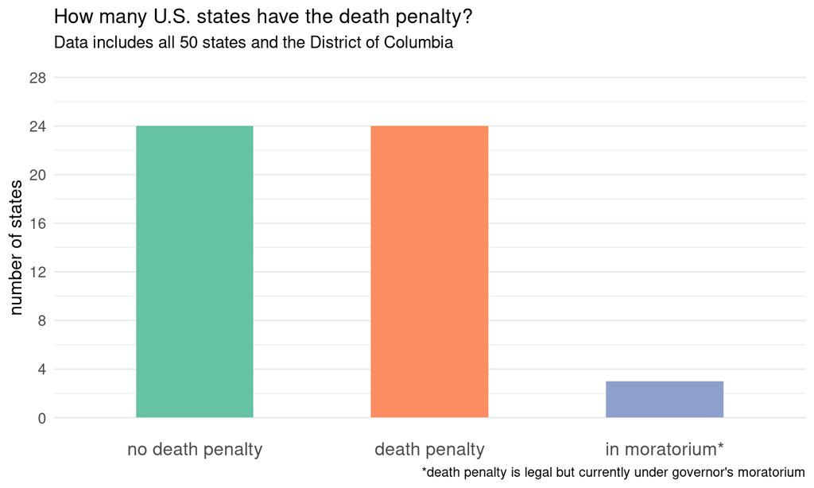

This is a serviceable plot, but kind of bland, right?

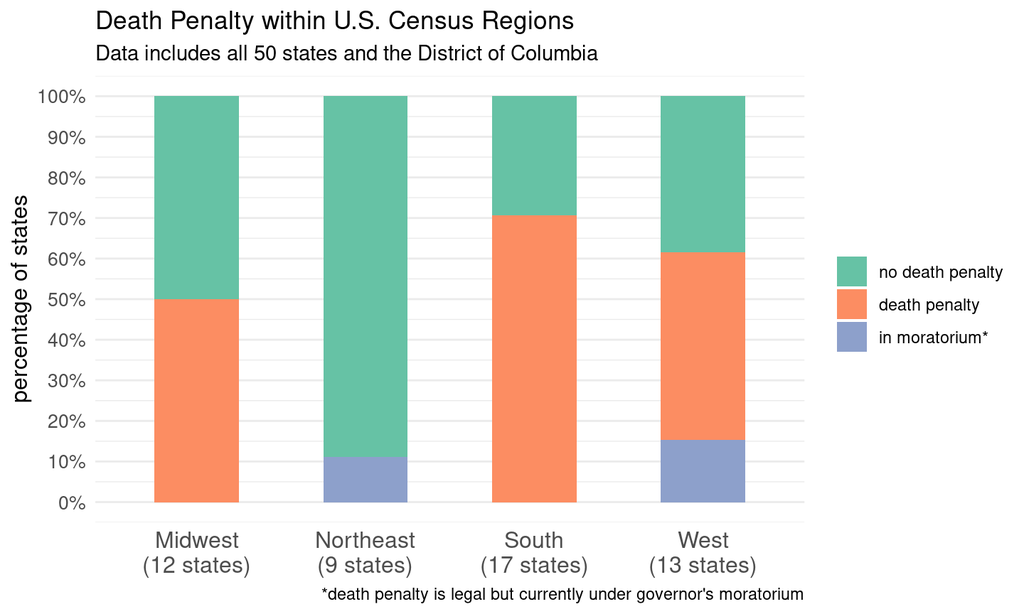

Do you notice any pattern in regions regarding proportions of states that do and do not have the death penalty?

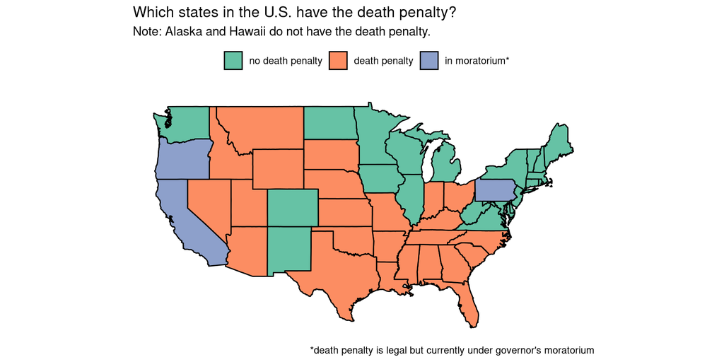

Do you notice any pattern in states that do and do not have the death penalty?

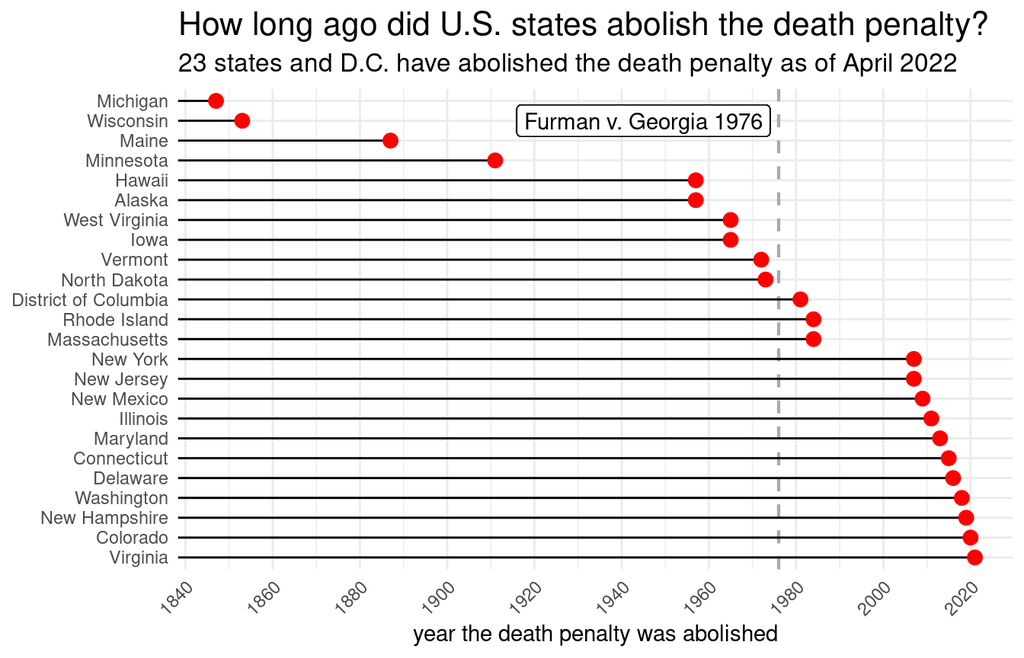

Figure Caption: This plot type is known as a Cleveland dot plot.

What is Furman vs. Georgia 1976 and why would I put it on this plot? Do you see any interesting patterns?

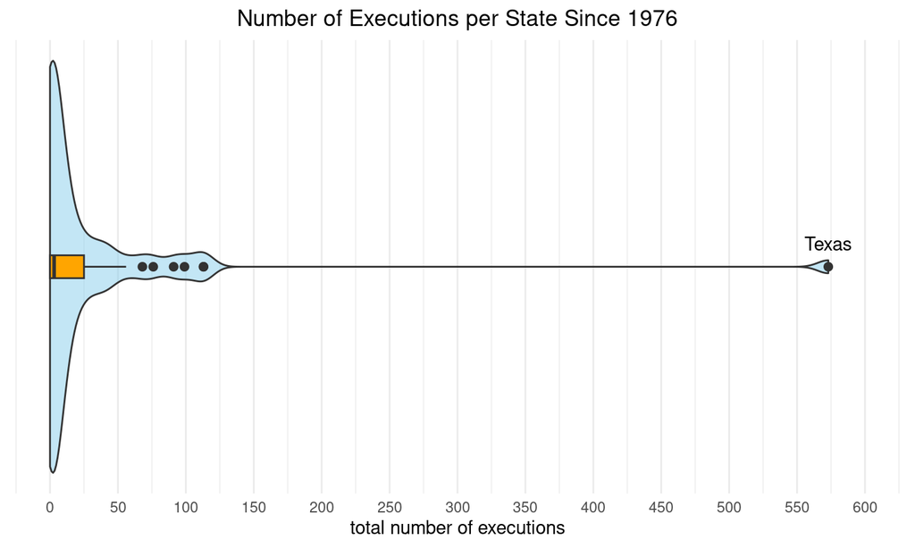

Wow, Texas — what’s up?!? Who are those smaller outlier states?